# Startup analysis

Nikodem Kijas

2025-06-13

## **Data import and cleaning.**

### We start the anylysis from importing data set using function import() from “rio” package.

```r
df <- import("startup_data.csv")
```

### We check is there any missing (NA) value in our dataset.

```r
sum(is.na(df))
```

```
## [1] 0
```

### We displaythe first and last rows of dataset.

```r
knitr::kable(head(df))
```

| Startup Name | Industry | Funding Rounds | Funding Amount (M USD) | Valuation (M USD) | Revenue (M USD) | Employees | Market Share (%) | Profitable | Year Founded | Region | Exit Status |
| --- | --- | --- | --- | --- | --- | --- | --- | --- | --- | --- | --- |
| Startup_1 | IoT | 1 | 101.09 | 844.75 | 67.87 | 1468 | 5.20 | 0 | 2006 | Europe | Private |
| Startup_2 | EdTech | 1 | 247.62 | 3310.83 | 75.65 | 3280 | 8.10 | 1 | 2003 | South America | Private |
| Startup_3 | EdTech | 1 | 109.24 | 1059.37 | 84.21 | 4933 | 2.61 | 1 | 1995 | South America | Private |
| Startup_4 | Gaming | 5 | 10.75 | 101.90 | 47.08 | 1059 | 2.53 | 0 | 2003 | South America | Private |
| Startup_5 | IoT | 4 | 249.28 | 850.11 | 50.25 | 1905 | 4.09 | 0 | 1997 | Europe | Acquired |
| Startup_6 | AI | 5 | 103.89 | 1541.76 | 12.56 | 1462 | 8.96 | 1 | 2004 | Europe | IPO |

```r
knitr::kable(tail(df))
```

|  | Startup Name | Industry | Funding Rounds | Funding Amount (M USD) | Valuation (M USD) | Revenue (M USD) | Employees | Market Share (%) | Profitable | Year Founded | Region | Exit Status |
| --- | --- | --- | --- | --- | --- | --- | --- | --- | --- | --- | --- | --- |
| 495 | Startup_495 | E-Commerce | 4 | 114.12 | 1503.71 | 79.19 | 4014 | 1.13 | 1 | 2015 | Europe | IPO |
| 496 | Startup_496 | EdTech | 2 | 181.86 | 2378.65 | 59.64 | 3331 | 0.58 | 1 | 1993 | Europe | Private |
| 497 | Startup_497 | AI | 2 | 107.34 | 1394.58 | 10.22 | 2223 | 5.85 | 0 | 2019 | South America | Private |
| 498 | Startup_498 | E-Commerce | 1 | 160.29 | 502.09 | 84.73 | 2222 | 4.32 | 0 | 2019 | Australia | Private |
| 499 | Startup_499 | Gaming | 5 | 234.65 | 2814.52 | 53.16 | 4972 | 5.53 | 0 | 2011 | Europe | Private |
| 500 | Startup_500 | HealthTech | 4 | 211.76 | 2563.17 | 84.19 | 2374 | 5.26 | 0 | 2000 | North America | Private |

## **Descriptive statistics.**

```r
numeric_cols <- df %>%
  select(where(is.numeric)) %>%
  colnames()


summary_df <- data.frame(
  Variable = character(),
  Min = numeric(),
  Max = numeric(),
  Mean = numeric(),
  Median = numeric(),
  SD = numeric(),
  Skewness = numeric(),
  Kurtosis = numeric(),
  stringsAsFactors = FALSE
)



for (var in numeric_cols) {
  x <- df[[var]]
  summary_df <- rbind(summary_df, data.frame(
    Variable = var,
    Min = min(x, na.rm = TRUE),
    Max = max(x, na.rm = TRUE),
    Mean = mean(x, na.rm = TRUE),
    Median = median(x, na.rm = TRUE),
    SD = sd(x, na.rm = TRUE),
    Skewness = skewness(x, na.rm = TRUE),
    Kurtosis = kurtosis(x, na.rm = TRUE)
  ))
}
```

```r
knitr::kable(summary_df)
```

| Variable | Min | Max | Mean | Median | SD | Skewness | Kurtosis |
| --- | --- | --- | --- | --- | --- | --- | --- |
| Funding Rounds | 1.00 | 5.00 | 2.95800 | 3.000 | 1.4409680 | 0.0572110 | -1.3261033 |
| Funding Amount (M USD) | 0.57 | 299.81 | 152.65676 | 156.005 | 86.6837110 | -0.0892263 | -1.1357880 |
| Valuation (M USD) | 2.43 | 4357.49 | 1371.80918 | 1222.580 | 978.2265787 | 0.6885319 | -0.1164603 |
| Revenue (M USD) | 0.12 | 99.71 | 49.32174 | 48.800 | 29.2676050 | -0.0106769 | -1.2428757 |
| Employees | 12.00 | 4984.00 | 2532.09200 | 2496.500 | 1385.4349207 | -0.0488833 | -1.1097968 |
| Market Share (%) | 0.10 | 10.00 | 5.09294 | 5.135 | 2.8076457 | -0.0402071 | -1.1305477 |
| Profitable | 0.00 | 1.00 | 0.43200 | 0.000 | 0.4958505 | 0.2737277 | -1.9289190 |
| Year Founded | 1990.00 | 2022.00 | 2006.04400 | 2006.000 | 9.3471280 | -0.0007858 | -1.1760053 |

### We calculated basic descriptive statistics such as min, max, mean, median, standard deviation, skewness and curtiosis for all numeric variables. The result show us structure and distribution of dataset.

```r
t.test(`Valuation (M USD)` ~ Profitable, data = df)
```

```
##
##  Welch Two Sample t-test
##
## data:  Valuation (M USD) by Profitable
## t = -2.0385, df = 430.64, p-value = 0.04211
## alternative hypothesis: true difference in means between group 0 and group 1 is not equal to 0
## 95 percent confidence interval:
##  -358.435433   -6.534362
## sample estimates:
## mean in group 0 mean in group 1
##        1292.976        1475.461
```

### The t-test of Valuation and Profiitable showed that the difference in avereage valuation between porfitable and non profitable is statistically valuable, because p-value is smaller than 0,05. So generally we can say that profitable startups have higher average valuation.

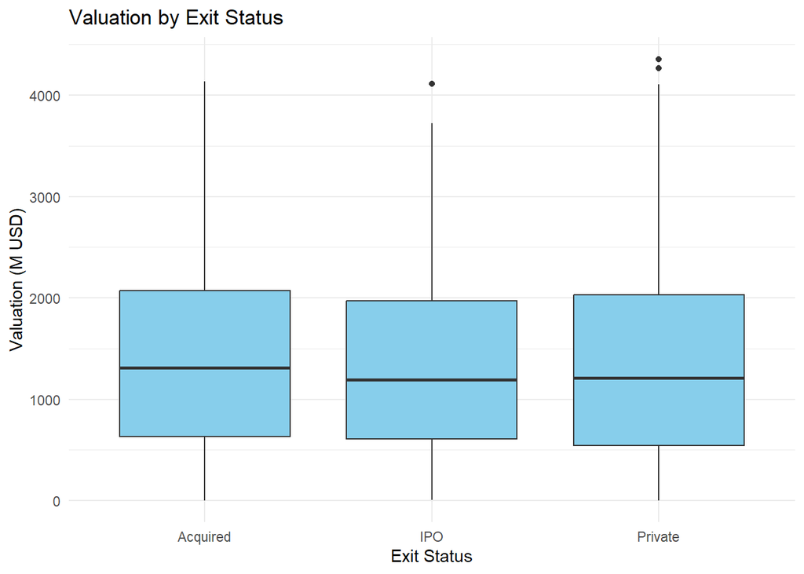

```r
ggplot(df, aes(x = `Exit Status`, y = `Valuation (M USD)`)) +
  geom_boxplot(fill = "skyblue") +
  labs(title = "Valuation by Exit Status",
       x = "Exit Status", y = "Valuation (M USD)") +
  theme_minimal()
```

### This boxplot show us distribution of valuation in different exit status. On the first look we can’t see any significant impact on valuation.

### So we will make more formal statistical test which is Anova test.

```r
anova_result <- aov(`Valuation (M USD)` ~ `Exit Status`, data = df)
summary(anova_result)
```

```
##                Df    Sum Sq Mean Sq F value Pr(>F)
## `Exit Status`   2    779097  389549   0.406  0.666
## Residuals     497 476727595  959210
```

### The anova test shows that difference of average startup valuation is not statistically significant, because p-value is much greater than 0.05. So we cannot say that exit status has an impact on startup valuation .

## **Visualisation of Variable Distributions.**

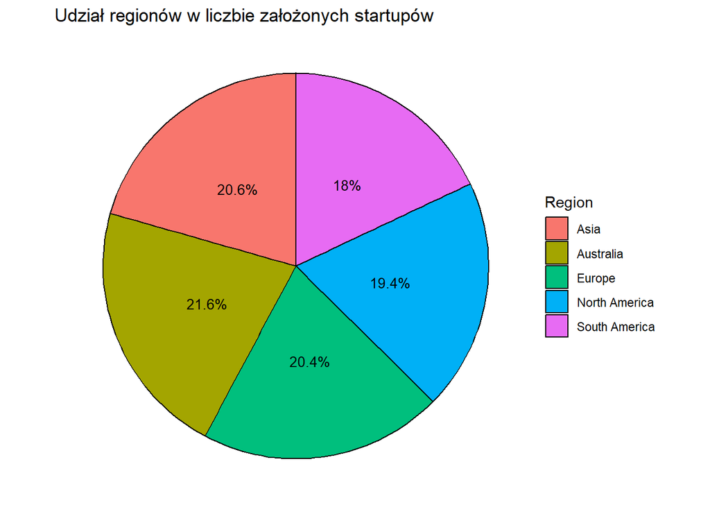

```r
region_counts <- df %>%
  count(Region) %>%
  mutate(percentage = n / sum(n) * 100,
         label = paste0( round(percentage, 1), "%"))


ggplot(region_counts, aes(x = "", y = n, fill = Region)) +
  geom_bar(stat = "identity", width = 1, color = "black") +
  coord_polar("y") +
  labs(title = "Udział regionów w liczbie założonych startupów") +
  theme_void() +
  geom_text(aes(label = label), position = position_stack(vjust = 0.5),
            size = 3.5)
```

### The pie chart shows the distributions of startups across different regions. Segments shows the percentage of Startups founded in every region.

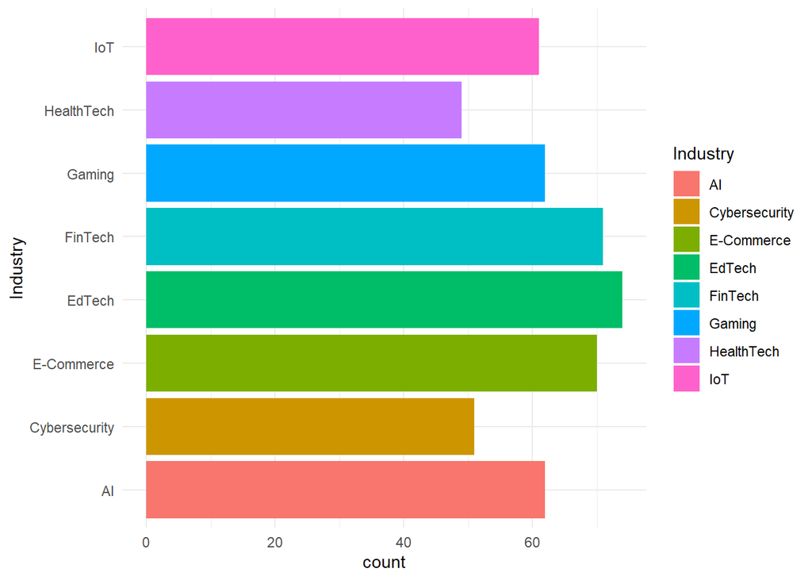

```r
ggplot(df, aes(x = Industry, fill=Industry))+
  geom_bar()+
  coord_flip()+
  theme_minimal()
```

### The bar chart displays the number of startups in each industry.

#### The visualisations from both charts indicate that data set is well prepared and has a variety data .

## **Visualisation of Relatshionships Between Variables.**

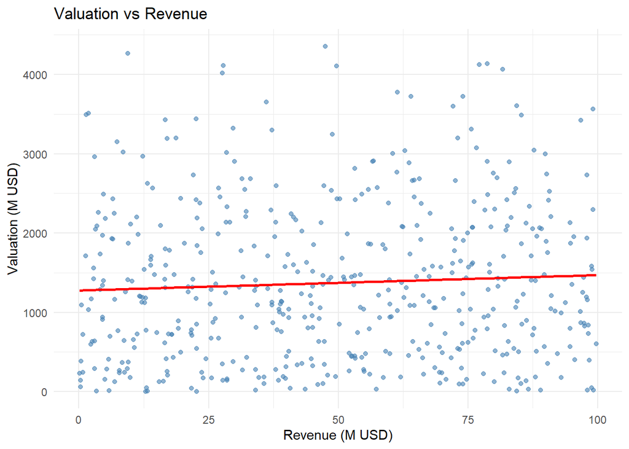

```r
ggplot(df, aes(x = `Revenue (M USD)`, y = `Valuation (M USD)`))+
  geom_point(alpha = 0.6, color = "steelblue") +
  geom_smooth(method = "lm", se = FALSE, color = "red") +
  labs(title = "Valuation vs Revenue",
       x = "Revenue (M USD)", y = "Valuation (M USD)") +
  theme_minimal()
```

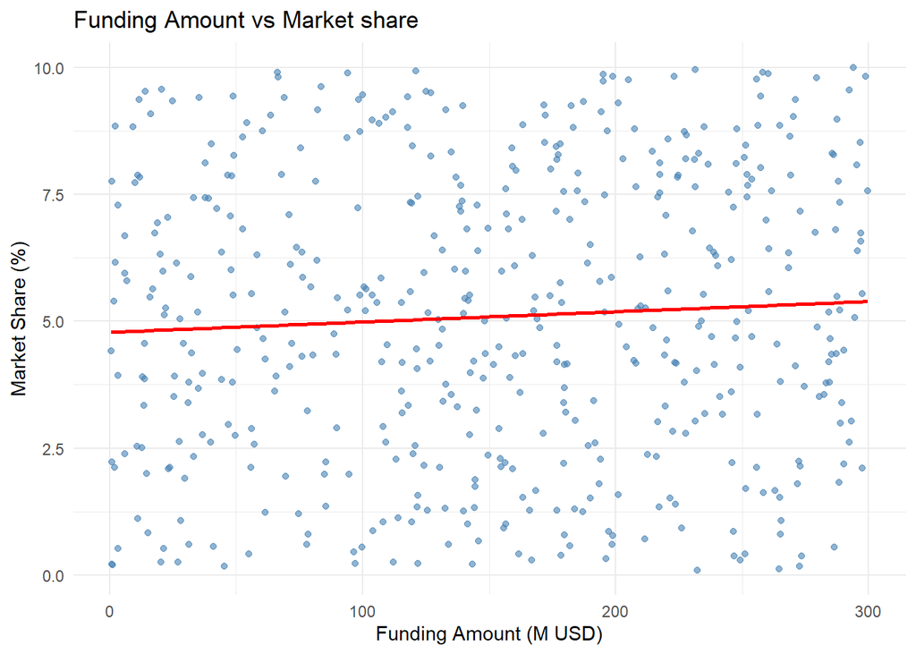

```r
ggplot(df, aes(x = `Funding Amount (M USD)`, y =`Market Share (%)`))+
  geom_point(alpha = 0.6, color = "steelblue") +
  geom_smooth(method = "lm", se = FALSE, color = "red") +
  labs(title = "Funding Amount vs Market share",
       x = "Funding Amount (M USD)", y = "Market Share (%)") +
  theme_minimal()
```

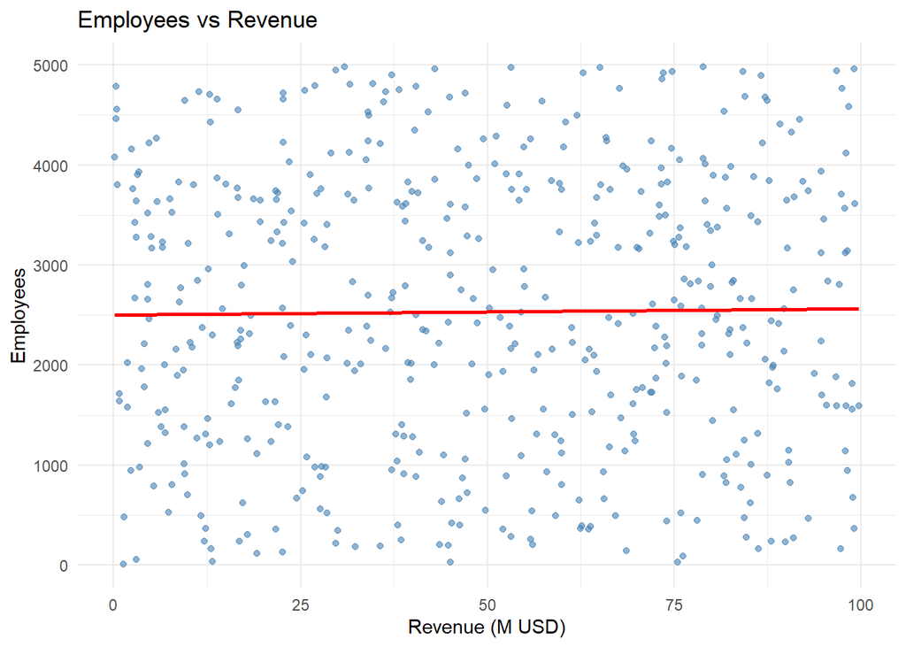

```r
ggplot(df, aes(x = df$`Revenue (M USD)`, y =df$Employees))+
  geom_point(alpha = 0.6, color = "steelblue") +
  geom_smooth(method = "lm", se = FALSE, color = "red") +
  labs(title = "Employees vs Revenue",
       x = "Revenue (M USD)", y = "Employees") +
  theme_minimal()
```

### The above scatterplots explore a linear relationship between the pairs of variables.

- Revenue vs Valuation
- Funding Amount vs Market share
- Revenue vs Number of Employees

### In each case, the linear regression line added by geom_smooth(method = “lm”) is nearly flat, which suggest that there is no stronger linear relationship between variables.

## **Simple Linear Regression Model.**

```r
model1 <- lm(`Valuation (M USD)` ~ `Revenue (M USD)`, data = df)
summary(model1)
```

```
##
## Call:
## lm(formula = `Valuation (M USD)` ~ `Revenue (M USD)`, data = df)
##
## Residuals:
##     Min      1Q  Median      3Q     Max
## -1451.0  -849.9  -123.9   646.8  2989.3
##
## Coefficients:
##                   Estimate Std. Error t value Pr(>|t|)
## (Intercept)       1275.835     85.730  14.882   <2e-16 ***
## `Revenue (M USD)`    1.946      1.495   1.301    0.194
## ---
## Signif. codes:  0 '***' 0.001 '**' 0.01 '*' 0.05 '.' 0.1 ' ' 1
##
## Residual standard error: 977.5 on 498 degrees of freedom
## Multiple R-squared:  0.003389,   Adjusted R-squared:  0.001388
## F-statistic: 1.694 on 1 and 498 DF,  p-value: 0.1937
```

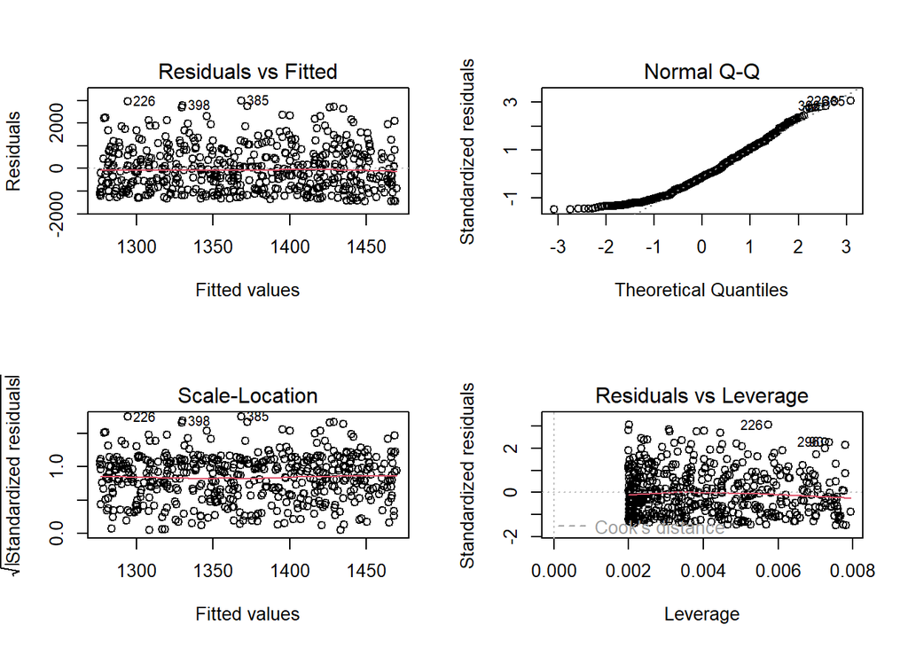

```r
par(mfrow = c(2, 2))
plot(model1)
```

```r
par(mfrow = c(1,1))
```

### The above is a simple model of linear regression to predict valuation based on revenue. However an R-squared value is low, so linear relationship is weak. Based on observation, logarithmic transformation was applied.

## **Log Transformed Linear Model**

```r
df$log_revenue <- log(df$`Revenue (M USD)` + 1)
df$log_valuation <- log(df$`Valuation (M USD)` + 1)

model_log <- lm(log_valuation ~ log_revenue, data = df)
summary(model_log)
```

```
##
## Call:
## lm(formula = log_valuation ~ log_revenue, data = df)
##
## Residuals:
##     Min      1Q  Median      3Q     Max
## -5.5116 -0.5172  0.3274  0.7815  1.6875
##
## Coefficients:
##             Estimate Std. Error t value Pr(>|t|)
## (Intercept)  6.42184    0.21015  30.558   <2e-16 ***
## log_revenue  0.10641    0.05616   1.895   0.0587 .
## ---
## Signif. codes:  0 '***' 0.001 '**' 0.01 '*' 0.05 '.' 0.1 ' ' 1
##
## Residual standard error: 1.165 on 498 degrees of freedom
## Multiple R-squared:  0.007158,   Adjusted R-squared:  0.005164
## F-statistic:  3.59 on 1 and 498 DF,  p-value: 0.0587
```

## After transformation, a new model was built. The result is better fitted than previous one, what can we see in higher R-squared value and more linear relationship.

## **Multiple Linear Regression Model.**

```r
model1 <- lm(`Valuation (M USD)` ~ `Revenue (M USD)` +
               `Funding Amount (M USD)`, data = df)
summary(model1)
```

```
##
## Call:
## lm(formula = `Valuation (M USD)` ~ `Revenue (M USD)` + `Funding Amount (M USD)`,
##     data = df)
##
## Residuals:
##      Min       1Q   Median       3Q      Max
## -1570.62  -336.99    14.86   334.96  1727.88
##
## Coefficients:
##                          Estimate Std. Error t value Pr(>|t|)
## (Intercept)              -48.6923    69.0453  -0.705    0.481
## `Revenue (M USD)`          1.0674     0.9086   1.175    0.241
## `Funding Amount (M USD)`   8.9603     0.3068  29.209   <2e-16 ***
## ---
## Signif. codes:  0 '***' 0.001 '**' 0.01 '*' 0.05 '.' 0.1 ' ' 1
##
## Residual standard error: 593.7 on 497 degrees of freedom
## Multiple R-squared:  0.6331, Adjusted R-squared:  0.6317
## F-statistic: 428.9 on 2 and 497 DF,  p-value: < 2.2e-16
```

```r
model2 <- lm(`Valuation (M USD)` ~ `Revenue (M USD)` +
               `Funding Amount (M USD)` +
               Employees + `Market Share (%)`, data = df)
summary(model2)
```

```
##
## Call:
## lm(formula = `Valuation (M USD)` ~ `Revenue (M USD)` + `Funding Amount (M USD)` +
##     Employees + `Market Share (%)`, data = df)
##
## Residuals:
##      Min       1Q   Median       3Q      Max
## -1585.18  -344.04     9.01   343.62  1793.50
##
## Coefficients:
##                            Estimate Std. Error t value Pr(>|t|)
## (Intercept)              -106.94993   94.06932  -1.137    0.256
## `Revenue (M USD)`           1.10251    0.90632   1.216    0.224
## `Funding Amount (M USD)`    8.93099    0.30680  29.110   <2e-16 ***
## Employees                  -0.01472    0.01916  -0.768    0.443
## `Market Share (%)`         19.29498    9.46400   2.039    0.042 *
## ---
## Signif. codes:  0 '***' 0.001 '**' 0.01 '*' 0.05 '.' 0.1 ' ' 1
##
## Residual standard error: 592.1 on 495 degrees of freedom
## Multiple R-squared:  0.6366, Adjusted R-squared:  0.6336
## F-statistic: 216.7 on 4 and 495 DF,  p-value: < 2.2e-16
```

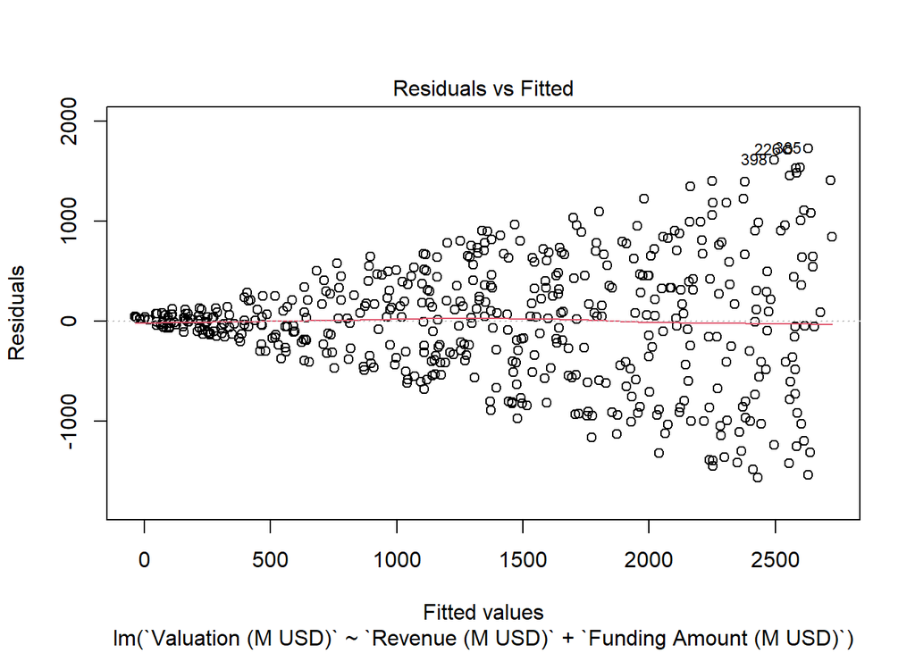

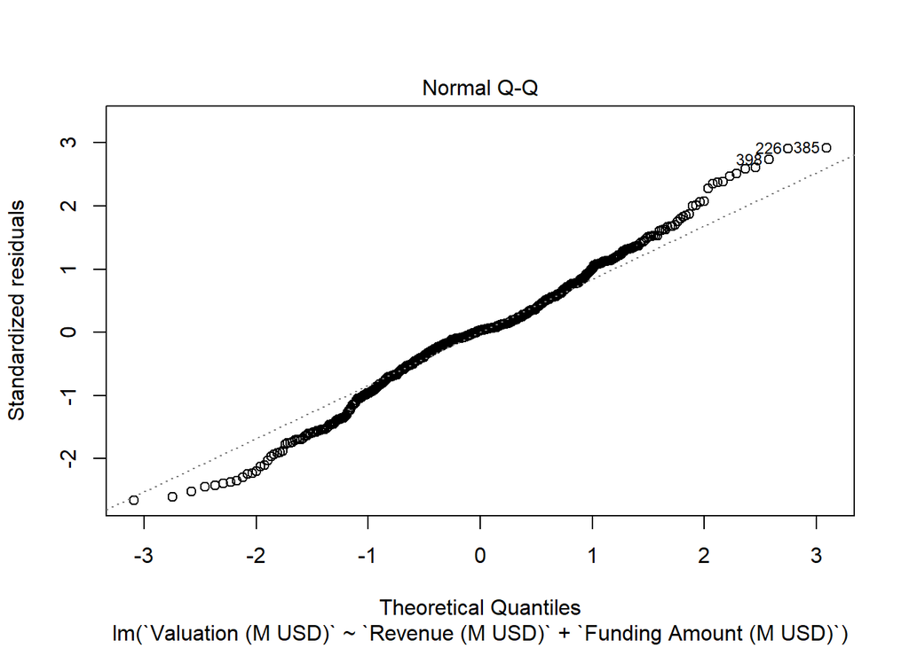

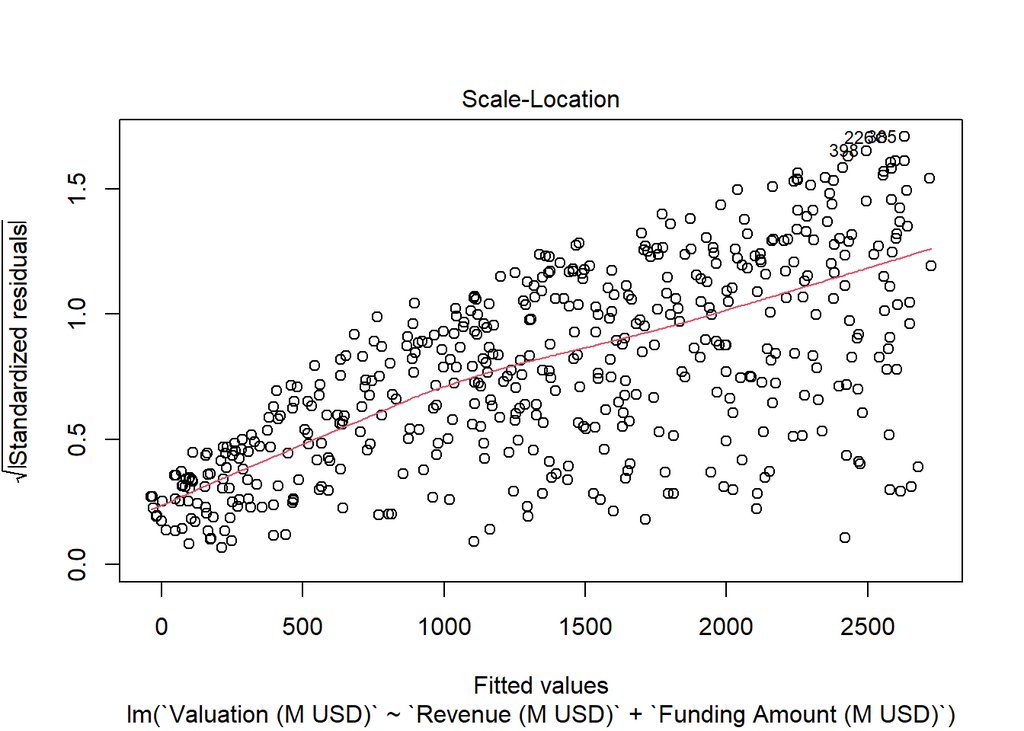

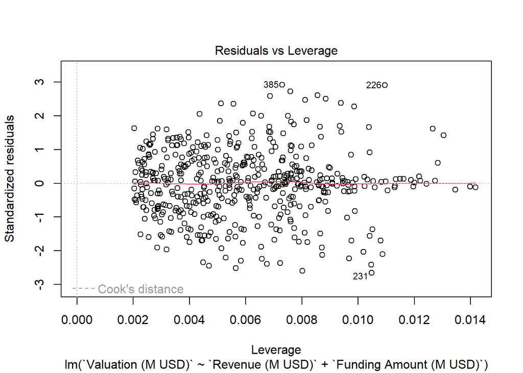

```r
plot(model1)
```

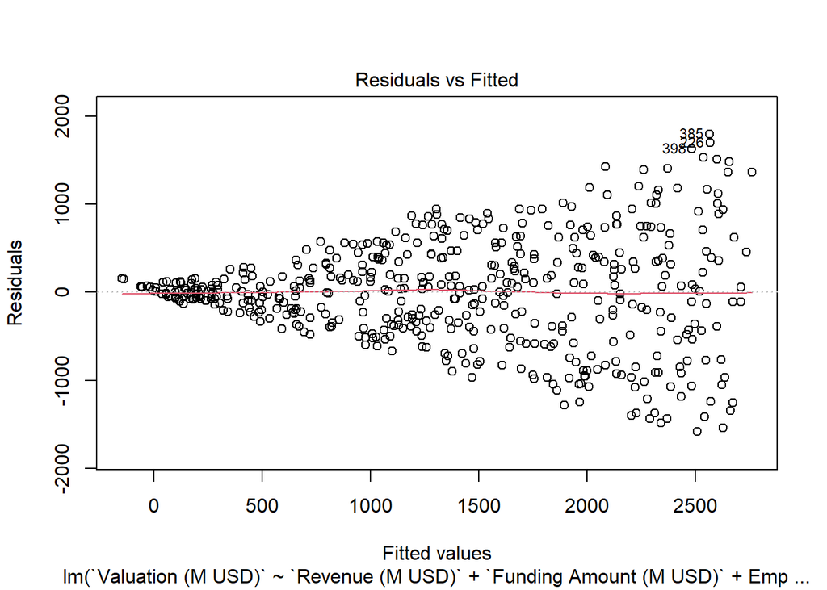

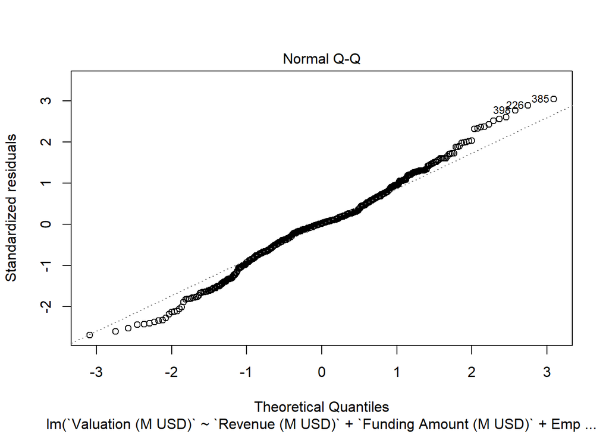

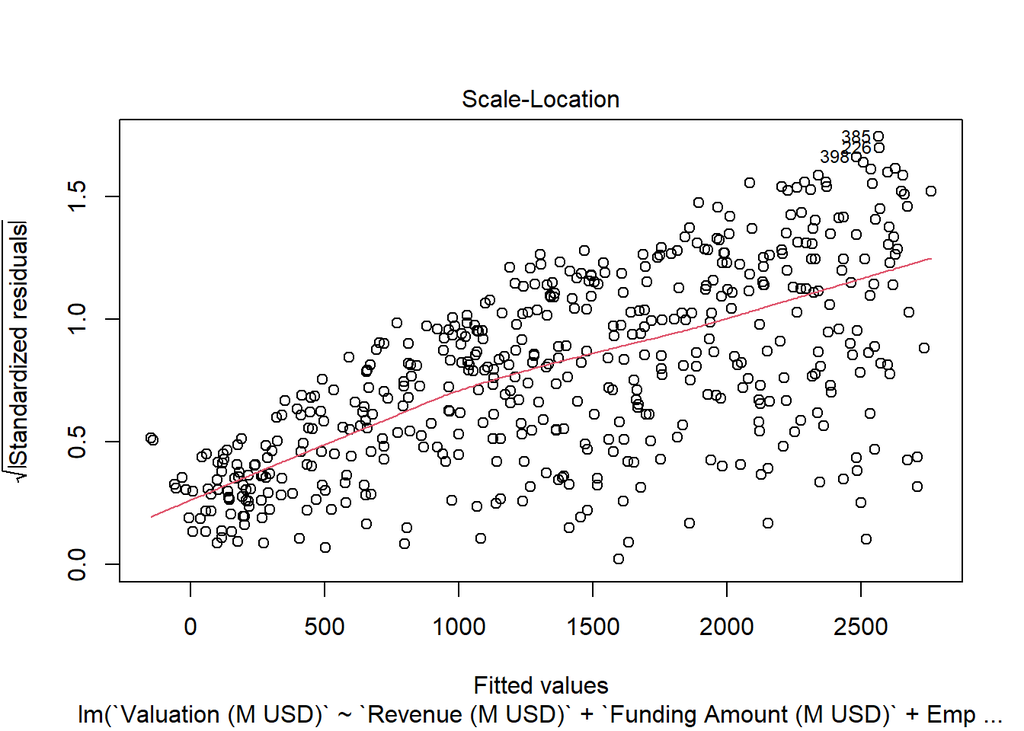

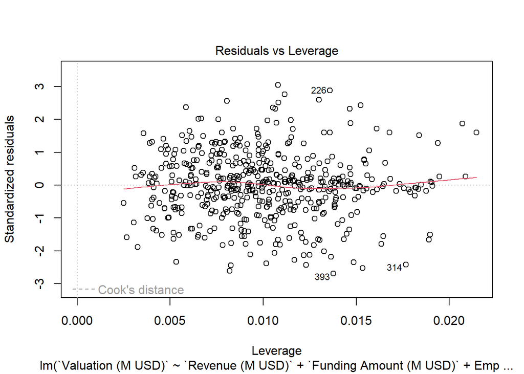

```r
plot(model2)
```

### Compared two linear regression models:

- model1 which includes Revenue and Funding amount
- model2 adds Employees and Market share to model1 ### Both models are statistically significant (p-value < 0,001). The difference between R-squared or Residual Standard Error is marginally. Even if the improvment is modest, model2 better capture the variation in valuation by including more variables.

## **Correlation Analysis**

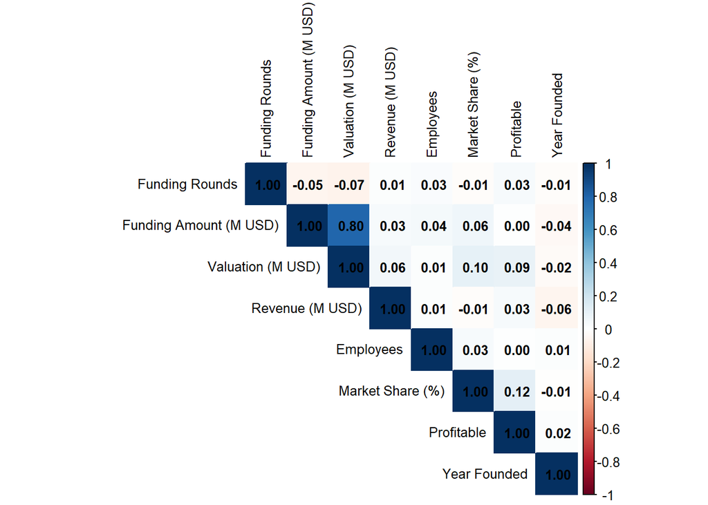

```r
df <- df %>% select(-log_revenue, -log_valuation)
numeric_data <- df[sapply(df, is.numeric)]

cor_matrix <- cor(numeric_data, use = "complete.obs")

corrplot(cor_matrix,
         method="color",
         type="upper",
         addCoef.col = "black",
         number.cex = 0.8,
         tl.cex = 0.8,
         tl.col = "black")
```

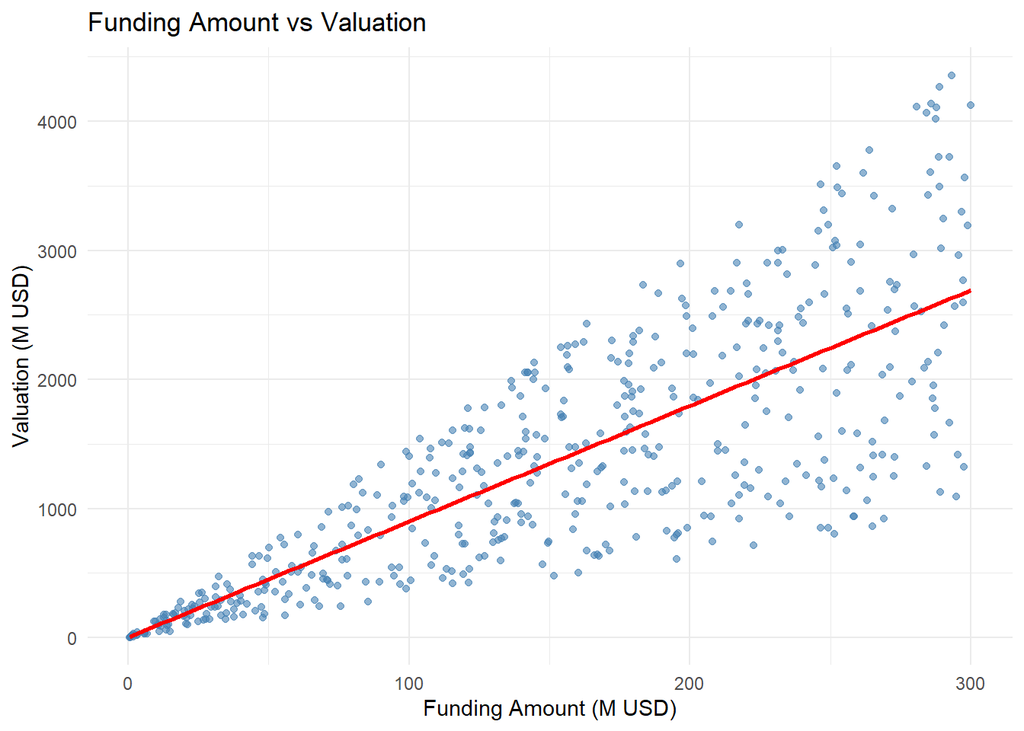

```r
ggplot(df, aes(x = `Funding Amount (M USD)`, y = `Valuation (M USD)`))+
  geom_point(alpha = 0.6, color = "steelblue") +
  geom_smooth(method = "lm", se = FALSE, color = "red") +
  labs(title = "Funding Amount vs Valuation",
       x = "Funding Amount (M USD)", y = "Valuation (M USD)") +
  theme_minimal()
```

### The scatter plot above represents relationship between Funding amount and Valuation. Red regression line confirms pattern that valuation increase when funding amount rise.

## **Time Series and Seasonality Analysis.**

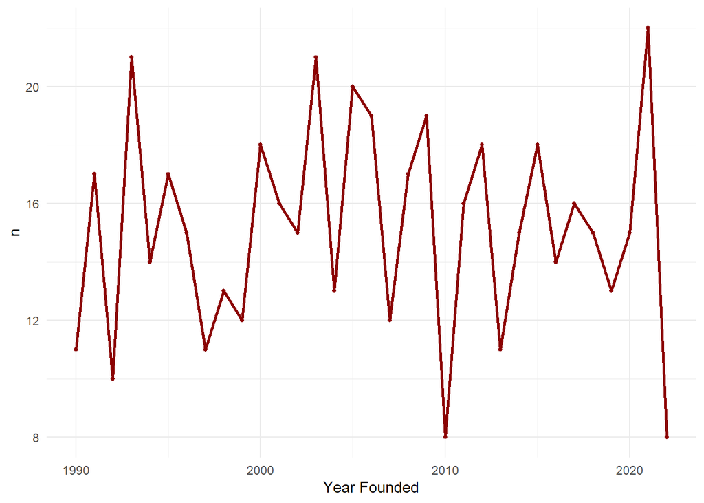

```r
founded_per_year <- df %>%
  count(`Year Founded`)

ggplot(founded_per_year, aes(x= `Year Founded`, y = n))+
  geom_point(color="dark red", size=1)+
  geom_line(color="dark red", size=1)+
  theme_minimal()
```

### The line plot represent amount of startups founded in each year. The trend appears irregular, without clear pattern or annual cycles.

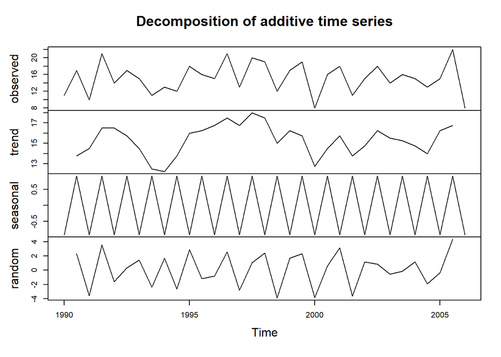

```r
ts_startups = ts(founded_per_year$n,
                      start = min(founded_per_year$`Year Founded`),
                      frequency = 2)



decomp_add <- decompose(ts_startups, type = "additive")
plot(decomp_add)
```

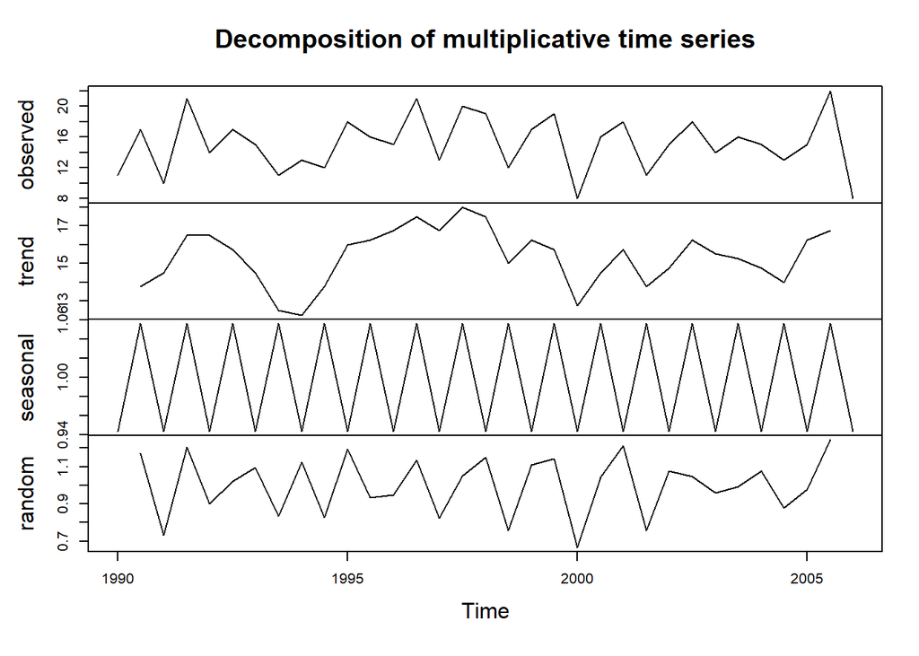

```r
decomp_mult <- decompose(ts_startups, type = "multiplicative")
plot(decomp_mult)
```

Unfortunately our dataset includes only year of each startup funding, so we can’t perform a proper seasonal analysis. To allow decompose to run we were forced to set fake frequency = 2 only to demonstrate seasonability analysis. We can’t get any valid information from this chunk.